# The forecaster’s toolbox

17 September, 2015

## Graphics

- The first thing to do in any data analysis task is to plot the data.
- Graphs enable many features of the data to be visualized including:
  - patterns,
  - unusual observations,
  - changes over time, and
  - relationships between variables.
- The features that are seen in plots of the data must then be incorporated, as far as possible, into the forecasting methods to be used.
- Just as the type of data determines what forecasting method to use, it also determines what graphs are appropriate.

## Time series plots

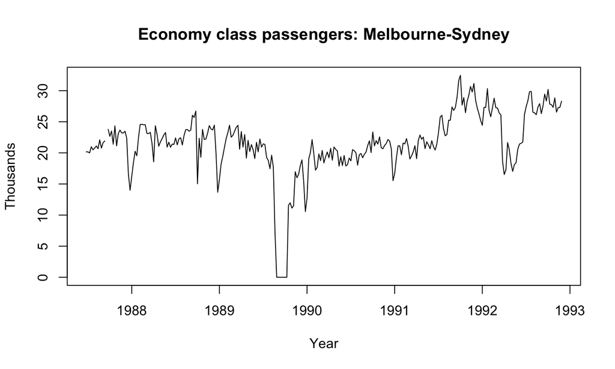

```r
plot(melsyd[,"Economy.Class"],
  main="Economy class passengers: Melbourne-Sydney",
  xlab="Year",ylab="Thousands")
```

The time plot immediately reveals some interesting features.

- There was a period in 1989 when no passengers were carried — this was due to an industrial dispute.
- There was a period of reduced load in 1992. This was due to a trial in which some economy class seats were replaced by business class seats.
- A large increase in passenger load occurred in the second half of 1991.
- There are some large dips in load around the start of each year. These are due to holiday effects. T- here is a long-term fluctuation in the level of the series which increases during 1987, decreases in 1989 and increases again through 1990 and 1991.
- There are some periods of missing observations.

## Another time series plot

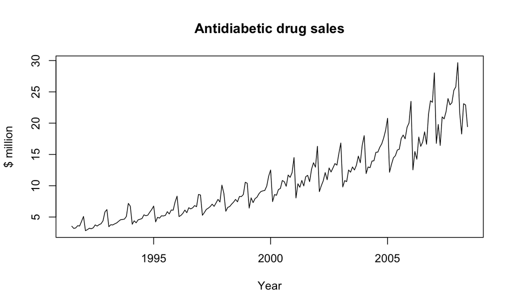

```r
plot(a10, ylab="$ million", xlab="Year",
     main="Antidiabetic drug sales")
```

- There is a clear and increasing trend.
- There is also a strong seasonal pattern that increases in size as the level of the series increases. (The sudden drop at the end of each year is caused by a government subsidisation scheme that makes it cost-effective for patients to stockpile drugs at the end of the calendar year.)

## Time series patterns

**A trend**

exists when there is a long-term increase or decrease in the data.

**A seasonal pattern**

occurs when a time series is affected by seasonal factors such as the time of the year or the day of the week.

**A cycle**

occurs when the data exhibit rises and falls that are not of a fixed period. These fluctuations are usually due to economic conditions and are often related to the "business cycle".

Seasonal patterns have a fixed and known length, while cyclic patterns have variable and unknown length.

## Seasonal plots

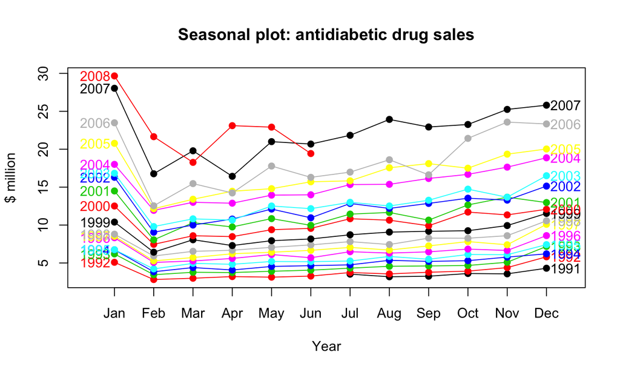

```r
seasonplot(a10,ylab="$ million", xlab="Year",
  main="Seasonal plot: antidiabetic drug sales",
  year.labels=TRUE, year.labels.left=TRUE, col=1:20, pch=19)
```

- There is a large jump in sales in January each year. Actually, these are probably sales in late December as customers stockpile before the end of the calendar year, but the sales are not registered with the government until a week or two later.
- The graph also shows that there was an unusually low number of sales in March 2008 (most other years show an increase between February and March).
- The small number of sales in June 2008 is probably due to incomplete counting of sales at the time the data were collected.

## Seasonal subseries plots

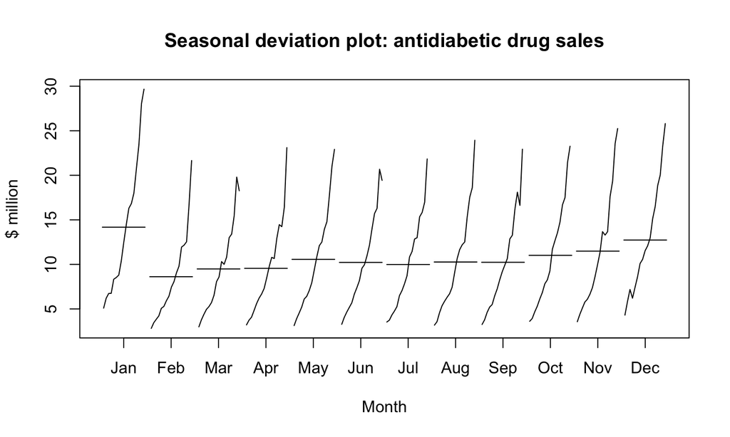

```r
monthplot(a10,ylab="$ million",xlab="Month",xaxt="n",
  main="Seasonal deviation plot: antidiabetic drug sales")
axis(1,at=1:12,labels=month.abb,cex=0.8)
```

## Scatterplots

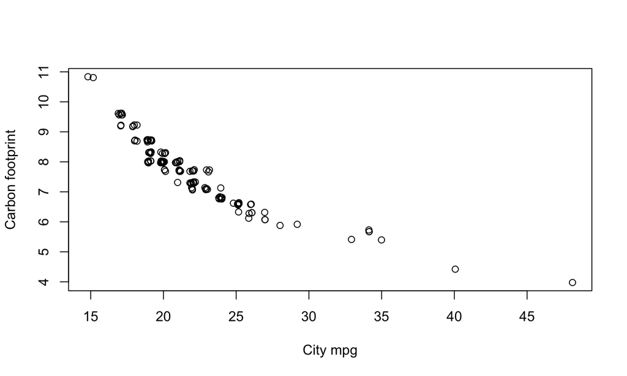

```r
plot(jitter(fuel[,5]), jitter(fuel[,8]), xlab="City mpg",
     ylab="Carbon footprint")
```

- The points are slightly "jittered" to prevent overlapping points.
- There is a strong non-linear relationship between the size of a car's carbon footprint and its city-based fuel economy.
- The strength of the relationship is good news for forecasting: for any cars not in this database, knowing the fuel economy of the car will allow a relatively accurate forecast of its carbon footprint.

## Scatterplot matrices

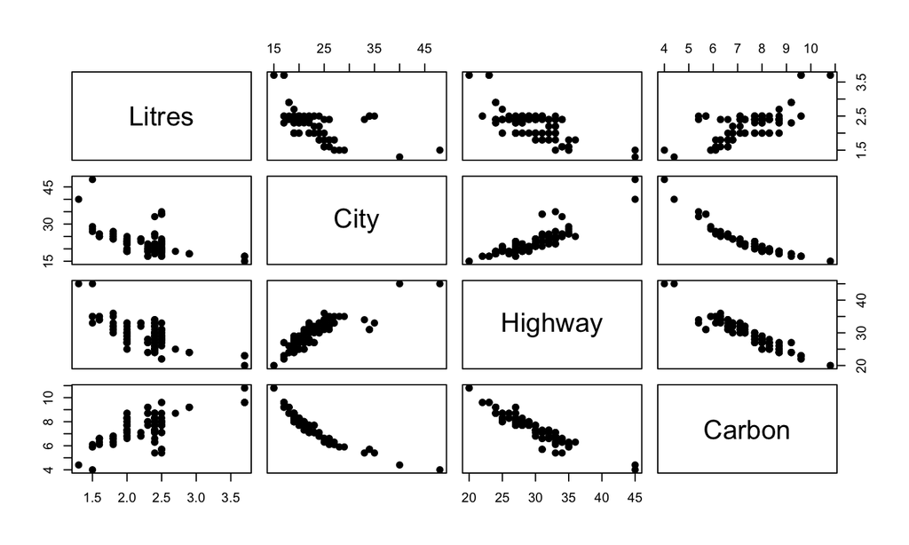

```r
pairs(fuel[,-c(1:2,4,7)], pch=19)
```

- The value of the scatterplot matrix is that it enables a quick view of the relationships between all pairs of variables.
- Outliers can also be seen. In this example, there are two vehicles that have very high highway mileage, small engines and low carbon footprints. These are hybrid vehicles: Honda Civic and Toyota Prius.

## Numerical data summaries

- Numerical summaries of data sets are widely used to capture some essential features of the data with a few numbers.
- A summary number calculated from the data is called a statistic.
- For a single data set, the most widely used statistics are the *average* and *median*.
- The most commonly used bivariate statistic is the *correlation coefficient*.

## Average

Suppose \(N\) denotes the total number of observations and \(x_i\) denotes the \(i\)th observation. Then the average can be written as \[ \bar{x} = \frac{1}{N}\sum_{i=1}^N x_{i} = (x_{1} + x_{2} + x_3 + \cdots + x_{N})/N\ .\] The average is also called the sample mean.

Consider the carbon footprint from 20 vehicles: \(x = \{4.0, 4.4, 5.9, 5.9, 6.1, 6.1, 6.1, 6.3, 6.3, 6.3, 6.6, 6.6, 6.6, \\6.6, 6.6, 6.6, 6.6, 6.8, 6.8, 6.8\}\).

In this example, \(N=20\) and \(x_i\) denotes the carbon footprint of vehicle \(i\).

Then the average carbon footprint is \[\bar{x} = \frac{1}{20}\sum_{i=1}^{20} x_i = (x_1+x_2+x_3+⋯+x_{20})/20 \\= (4.0+4.4+5.9+⋯+6.8+6.8+6.8)/20 \\= 124/20 = 6.2\ \mbox{tons CO2.}\]

## Median

The median is the middle observation when the data are placed in order.

In this case, there are 20 observations and so the median is the average of the 10th and 11th largest observations. That is

\[median=(6.3+6.6)/2=6.45\ .\]

*Percentiles* are useful for describing the distribution of data. For example, 90% of the data are no larger than the 90th percentile.

In the carbon footprint example, the 90th percentile is 6.8 because 90% of the data (18 observations) are less than or equal to 6.8. Similarly, the 75th percentile is 6.6 and the 25th percentile is 6.1.

The median is the 50th percentile.

## Measures of spread

A useful measure of how spread out the data are is the *interquartile range* or IQR. This is simply the difference between the 75th and 25th percentiles. Thus it contains the middle 50% of the data. For the example,

\[IQR=(6.6−6.1)=0.5\ .\]

An alternative and more common measure of spread is the *standard deviation*. This is given by the formula

\[s=\sqrt{\frac{1}{N−1}\sum_{i=1}^N (x_i−\bar{x})^2}.\]

In the example, the standard deviation is

\[s=\sqrt{\frac{1}{19}[(4.0−6.2)^2+(4.4−6.2)^2+⋯+(6.8−6.2)^2]}=0.74.\]

```r
fuel2 <- fuel[fuel$Litres<2,]
summary(fuel2[,"Carbon"])
```

```
##    Min. 1st Qu.  Median    Mean 3rd Qu.    Max.
##    4.00    6.10    6.45    6.20    6.60    6.80
```

```r
sd(fuel2[,"Carbon"])
```

```
## [1] 0.7440996
```

## Correlation coefficient

measures the strength of the relationship between two variables and can be written as

\[r = \frac{\sum (x_{i} - \bar{x})(y_{i}-\bar{y})}{\sqrt{\sum(x_{i}-\bar{x})^2}\sqrt{\sum(y_{i}-\bar{y})^2}} \ ,\] where the first variable is denoted by \(x\) and the second variable by \(y\).

The correlation coefficient only measures the strength of the *linear* relationship; it is possible for two variables to have a strong non-linear relationship but low correlation coefficient.

The value of \(r\) always lies between -1 and 1 with negative values indicating a negative relationship and positive values indicating a postive relationship.

For example, the correlation between the carbon footprint and city mpg variables shown in the figure above is -0.9.

The value is negative because the carbon footprint decreases as the city mpg increases.

While a value of -0.9 is very high, the relationship is even stronger than that number suggests due to its nonlinear nature.

```r
cor(fuel[,5], fuel[,8])
```

```
## [1] -0.9079411
```

## Correlation examples

[figure not shown]

Scatterplots of data sets with different levels of correlation.

## Correlation examples

[figure not shown]

Each of these plots has a correlation coefficient of 0.82. This shows how important it is not to rely only on correlation coefficients but also to look at the plots of the data.

## Autocorrelation

Just as correlation measures the extent of a linear relationship between two variables, autocorrelation measures the linear relationship between *lagged values* of a time series.

There are several autocorrelation coefficients, depending on the lag length.

For example, \(r_{1}\) measures the relationship between \(y_{t}\) and \(y_{t-1}\), \(r_{2}\) measures the relationship between \(y_{t}\) and \(y_{t-2}\), and so on.

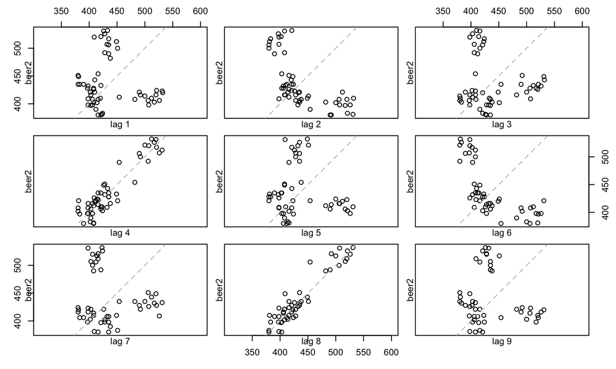

```r
beer2 <- window(ausbeer, start=1992, end=2006)
lag.plot(beer2, lags=9, do.lines=FALSE)
```

The value of \(r_{k}\) can be written as

\[r_{k} = \frac{\sum\limits_{t=k+1}^T (y_{t}-\bar{y})(y_{t-k}-\bar{y})}{\sum\limits_{t=1}^T (y_{t}-\bar{y})^2},\]

where \(T\) is the length of the time series.

The first nine autocorrelation coefficients for the beer production data are given in the following table.

| \(r_1\) | \(r_2\) | \(r_3\) | \(r_4\) | \(r_5\) | \(r_6\) | \(r_7\) | \(r_8\) | \(r_9\) |
| --- | --- | --- | --- | --- | --- | --- | --- | --- |
| -0.126 | -0.650 | -0.094 | 0.863 | -0.099 | -0.642 | -0.098 | 0.834 | -0.116 |

## Autocorrelation function (ACF) or correlogram

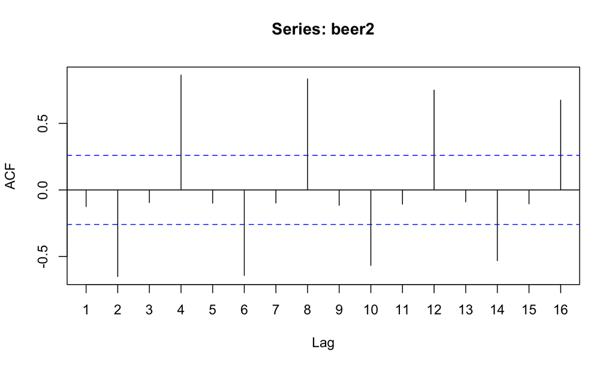

```r
Acf(beer2)
```

## White noise

Series that show no autocorrelation are called "white noise".

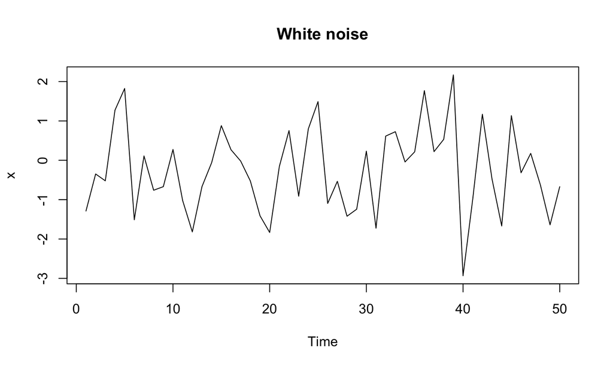

```r
set.seed(30); x <- ts(rnorm(50)); plot(x, main="White noise")
```

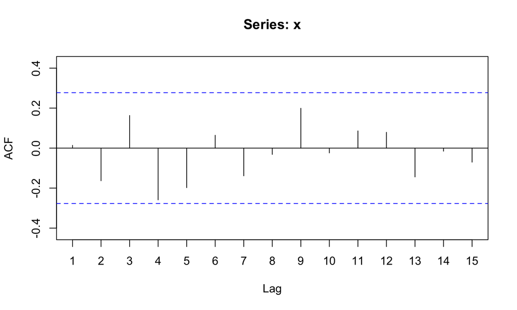

```r
Acf(x)
```

For a white noise series, we expect 95% of the spikes in the ACF to lie within \(\pm 2/\sqrt{T}\). Here \(T=50\): \(\pm 2/\sqrt{50} = \pm 0.28\).

## Some simple forecasting methods

Some forecasting methods are very simple and surprisingly effective. Here are four methods that we will use as benchmarks for other forecasting methods.

1. Average method
2. Naïve method
3. Seasonal naïve method
4. Drift method

## Average method

Here, the forecasts of all future values are equal to the mean of the historical data:

\[\hat{y}_{T+h|T} = \bar{y} = (y_{1}+\dots+y_{T})/T \ .\]

The notation \(\hat{y}_{T+h|T}\) is a short-hand for the estimate of \(y_{T+h}\) based on the data \(y_1,\dots,y_T\).

```r
meanf(y, h)
# y contains the time series
# h is the forecast horizon
```

This method can also be used for cross-sectional data (when we are predicting a value not included in the data set). Then the prediction for values not observed is the average of those values that have been observed.

## Naïve method

All forecasts are simply set to be the value of the last observation. That is, the forecasts of all future values are set to be \(y_T\), where \(y_T\) is the last observed value.

```r
naive(y, h)
rwf(y, h) # Alternative
```

This method works remarkably well for many economic and financial time series.

## Seasonal naïve method

In this case, we set each forecast to be equal to the last observed value from the same season of the year (e.g., the same month of the previous year).

- For example, with monthly data, the forecast for all future February values is equal to the last observed February value.
- With quarterly data, the forecast of all future Q2 values is equal to the last observed Q2 value (where Q2 means the second quarter).
- Similar rules apply for other months and quarters, and for other seasonal periods.

```r
snaive(y, h)
```

## Drift method

A variation on the naïve method is to allow the forecasts to increase or decrease over time, where the amount of change over time (called the drift) is set to be the average change seen in the historical data.

So the forecast for time \(T+h\) is given by

\[y_{T} + \frac{h}{T-1}\sum_{t=2}^T (y_{t}-y_{t-1}) = y_{T} + h \left( \frac{y_{T} -y_{1}}{T-1}\right) \ .\]

This is equivalent to drawing a line between the first and last observation, and extrapolating it into the future.

```r
rwf(y, h, drift=TRUE)
```

## Example 1

The first three methods applied to the quarterly beer production data.

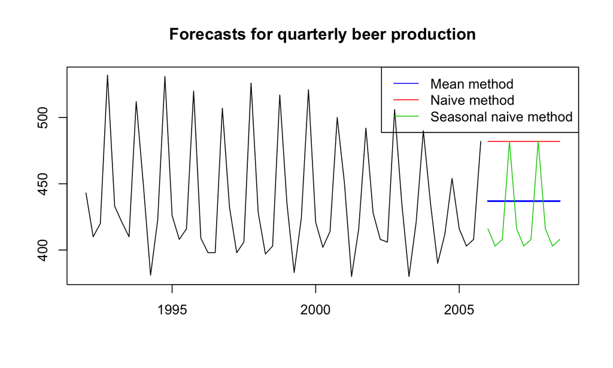

```r
beer2 <- window(ausbeer,start=1992,end=2006-.1)
beerfit1 <- meanf(beer2, h=11)
beerfit2 <- naive(beer2, h=11)
beerfit3 <- snaive(beer2, h=11)

plot(beerfit1, plot.conf=FALSE,
  main="Forecasts for quarterly beer production")
lines(beerfit2$mean,col=2)
lines(beerfit3$mean,col=3)
legend("topright",lty=1,col=c(4,2,3),
  legend=c("Mean method","Naive method","Seasonal naive method"))
```

## Example 2

Here the non-seasonal methods were applied to a series of 250 days of the Dow Jones Index.

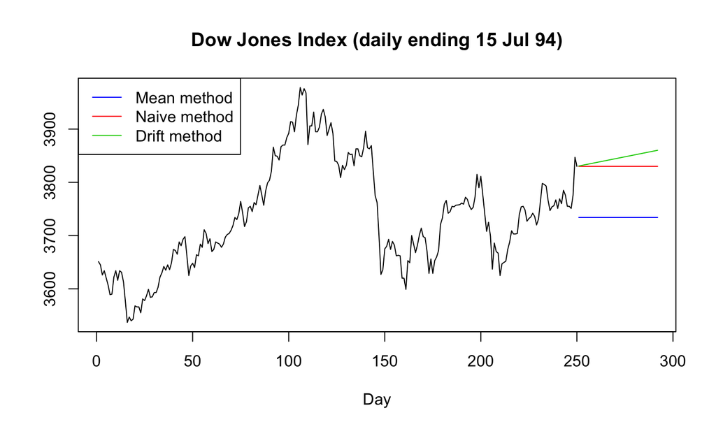

```r
dj2 <- window(dj,end=250)
plot(dj2,main="Dow Jones Index (daily ending 15 Jul 94)",
  ylab="",xlab="Day",xlim=c(2,290))
lines(meanf(dj2,h=42)$mean,col=4)
lines(rwf(dj2,h=42)$mean,col=2)
lines(rwf(dj2,drift=TRUE,h=42)$mean,col=3)
legend("topleft",lty=1,col=c(4,2,3),
  legend=c("Mean method","Naive method","Drift method"))
```

## Transformations and adjustments

Adjusting the historical data can often lead to a simpler forecasting model. Let's look at four kinds of adjustments:

1. mathematical transformations,
2. calendar adjustments,
3. population adjustments, and
4. inflation adjustments.

The purpose of these transformations and adjustments is to simplify the patterns in the historical data by removing known sources of variation or by making the pattern more consistent across the whole data set.

Simpler patterns usually lead to more accurate forecasts!

## Mathematical transformations

If the data show variation that increases or decreases with the level of the series, then a log-transformation can be useful.

If we denote the original observations as \(y_{1},\dots,y_{T}\) and the transformed observations as \(w_{1}, \dots, w_{T}\), then \(w_t = \log(y_t)\).

Logarithms are useful because they are interpretable: changes in a log value are relative (or percentage) changes on the original scale.

Another useful feature of log transformations is that they constrain the forecasts to stay positive on the original scale.

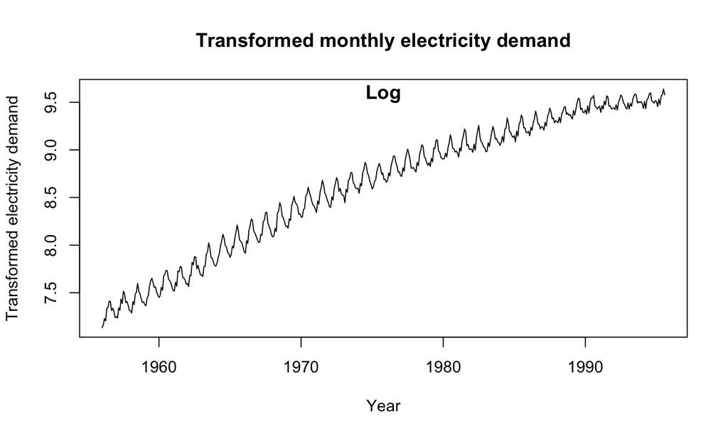

```r
plot(log(elec), ylab="Transformed electricity demand",
 xlab="Year", main="Transformed monthly electricity demand")
title(main="Log",line=-1)
```

A useful family of transformations that includes logarithms and power transformations is the family of "Box-Cox transformations", which depend on the parameter \(\lambda\) and are defined as follows:

\[ w_t = \begin{cases} \log(y_t) & \text{if $\lambda=0$}; \\ (y_t^\lambda-1)/\lambda & \text{otherwise}. \end{cases}\]

Having chosen a transformation, we need to forecast the transformed data. Then, we need to reverse the transformation (or *back-transform*) to obtain forecasts on the original scale. The reverse Box-Cox transformation is given by

\[ y_{t} = \begin{cases} \exp(w_{t}) & \text{if $\lambda=0$}; \\ (\lambda w_t+1)^{1/\lambda} & \text{otherwise}.\end{cases}\]

Features of power transformations

- If some \(y_{t}\leq0\), no power transformation is possible unless all observations are adjusted by adding a constant to all values.
- Choose a simple value of \(\lambda\). It makes explanations easier.
- Forecasting results are relatively insensitive to the value of \(\lambda\).
- Often no transformation is needed.
- Transformations sometimes make little difference to the forecasts but have a large effect on prediction intervals.

[See the impact of different \(\lambda\) values](https://www.otexts.org/sites/default/files/fpp/images/telec.gif)

A good value of \(\lambda\) is one which makes the size of the seasonal variation about the same across the whole series.

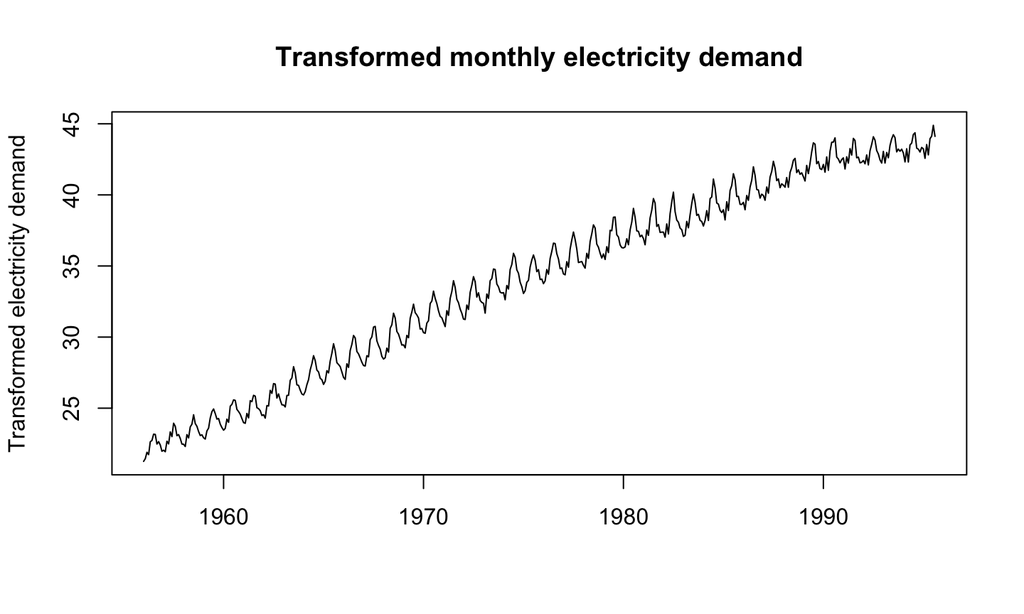

```r
# The BoxCox.lambda() function will choose a value of lambda for you.
lambda <- BoxCox.lambda(elec) # = 0.27;
plot(BoxCox(elec,lambda), ylab="Transformed electricity demand",
 xlab="", main="Transformed monthly electricity demand")
```

## Calendar adjustments

Some variation seen in seasonal data may be due to simple calendar effects. In such cases, it is usually much easier to remove the variation before fitting a forecasting model.

If you are studying monthly milk production on a farm, then there will be variation between the months simply because of the different numbers of days in each month in addition to seasonal variation across the year.

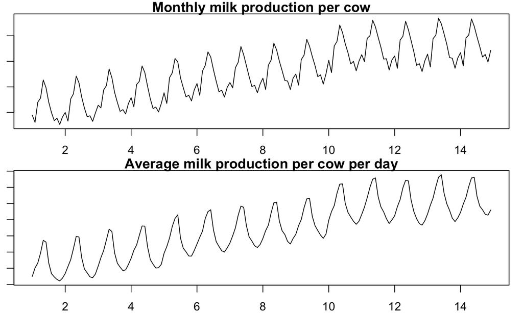

```r
monthdays <- rep(c(31,28,31,30,31,30,31,31,30,31,30,31),14)
monthdays[26 + (4*12)*(0:2)] <- 29
par(mfrow=c(2,1), mar=c(2,1,1,1))
plot(milk, main="Monthly milk production per cow",
  ylab="Pounds",xlab="Years")
plot(milk/monthdays, main="Average milk production per cow per day",
  ylab="Pounds", xlab="Years")
```

The simpler seasonal pattern in the average daily production plot compared to the average monthly production plot is because we effectively removed the variation due to the different month lengths.

## Population adjustments

Any data that are affected by population changes can be adjusted to give per-capita data. Consider the data per person (or per thousand or per million people) rather than the total.

- If you are studying the number of hospital beds in a particular region over time, the results are much easier to interpret if you remove the effect of population changes by considering number of beds per thousand people.
- Then you can see if there have been real increases in the number of beds, or whether the increases are entirely due to population increases.
- It is possible for the total number of beds to increase, but the number of beds per thousand people to decrease (population is increasing faster than the number of hospital beds.)
- For most data that are affected by population changes, it is best to use per-capita data rather than the totals.

## Inflation adjustments

Data that are affected by the value of money are best adjusted before modelling.

- A $200,000 house this year is not the same as a $200,000 house twenty years ago. For this reason, financial time series are usually adjusted so all values are stated in dollar values from a particular year. For example, the house price data may be stated in year 2000 dollars.
- To make these adjustments a price index is used. If \(z_t\) denotes the price index and \(y_t\) denotes the original house price in year \(t\), then \(x_t=y_t/z_t∗z_{2000}\) gives the adjusted house price at year 2000 dollar values.
- Price indexes are often constructed by government agencies. For consumer goods, a common price index is the Consumer Price Index (or CPI).

## Scale dependent forecast accuracy measures

Let \(y_{i}\) denote the \(i\)th observation and \(\hat{y}_{i}\) denote a forecast of \(y_{i}\).

The forecast error is \(e_{i}=y_{i}-\hat{y}_{i}\), which is on the same scale as the data. Accuracy measures that are based on \(e_{i}\) are therefore *scale-dependent* and cannot be used to make comparisons between series that are on different scales.

The two most commonly used scale-dependent measures are based on the absolute errors or squared errors:

\[ \begin{align*} \text{Mean absolute error: MAE} & = \text{mean}(|e_{i}|),\\ \text{Root mean squared error: RMSE} & = \sqrt{\text{mean}(e_{i}^2)}. \end{align*} \]

## Percentage errors

The percentage error is given by \(p_{i} = 100 e_{i}/y_{i}\).

Percentage errors have the advantage of being scale-independent, and so are frequently used to compare forecast performance between different data sets. The most commonly used measure is:

\[\text{Mean absolute percentage error: MAPE} = \text{mean}(|p_{i}|).\] Measures based on percentage errors have the disadvantage of having extreme values for \(y_{i} \approx 0\).

Another problem with percentage errors is that they assume a meaningful zero (not satisfied when measuring the accuracy of temperature forecasts on the Fahrenheit or Celsius scales.)

## Scaled errors

Scaled errors are an alternative to using percentage errors when comparing forecast accuracy across series on different scales. The errors can be scaled using the MAE from a simple forecast method.

For a non-seasonal time series, a useful way to define a scaled error uses naïve forecasts:

\[q_{j} = \dfrac{e_{j}}{\dfrac{1}{T-1}\sum_{t=2}^T |y_{t}-y_{t-1}|} \ ,\]

where \(y_{t}-y_{t-1}\) is the error of the naïve forecast.

Because the numerator and denominator both involve values on the scale of the original data, \(q_{j}\) is independent of the scale of the data.

- A scaled error is less than one if it arises from a better forecast than the average naïve forecast computed on the training data.
- Conversely, it is greater than one if the forecast is worse than the average naïve forecast computed on the training data.

For seasonal time series, a scaled error can be defined using seasonal naïve forecasts:

\[q_{j} = \dfrac{e_{j}}{\dfrac{1}{T-m}\sum_{t=m+1}^T |y_{t}-y_{t-m}|}.\]

For cross-sectional data, a scaled error can be defined as

\[q_{j} = \dfrac{e_{j}}{\dfrac{1}{N}\sum_{i=1}^N |y_i-\bar{y}|}.\]

In this case, the comparison is with the mean forecast. (This doesn't work so well for time series data as there may be trends and other patterns in the data, making the mean a poor comparison. Hence, the naïve forecast is recommended when using time series data.)

The *mean absolute scaled error* is simply

\[\text{MASE} = \text{mean}(|q_{j}|).\]

Similarly, a *root mean squared scaled error* (RMSSE) can be defined where the errors (on the training data and test data) are squared instead of using absolute values. For example, using the naïve forecasts:

\[q_{j} = \dfrac{e_{j}}{\sqrt{\dfrac{1}{T-1}\sum_{t=2}^T (y_{t}-y_{t-1})^2}}.\]

## Example 1

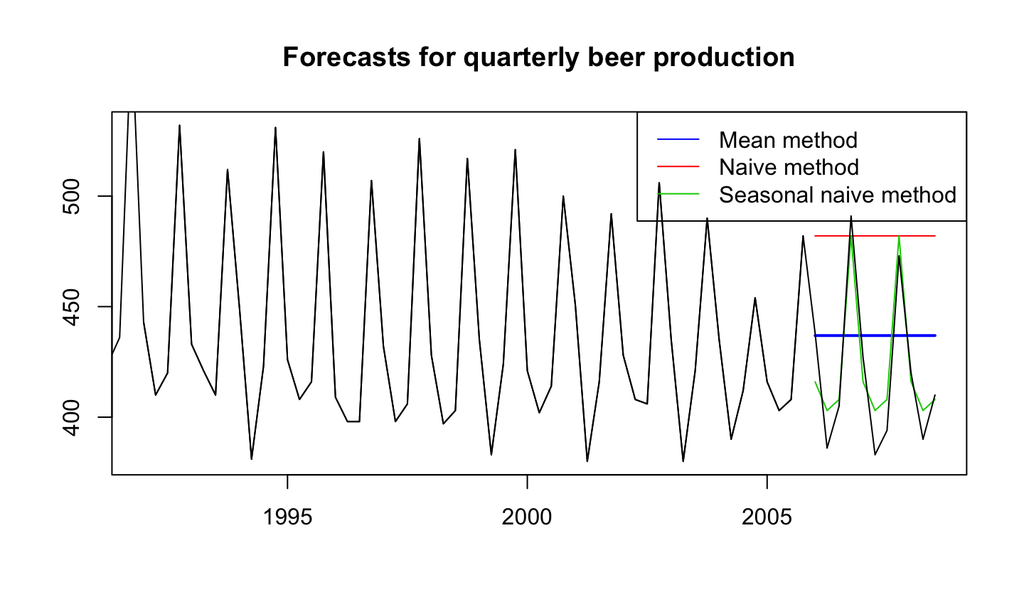

```r
beer2 <- window(ausbeer,start=1992,end=2006-.1)

beerfit1 <- meanf(beer2,h=11)
beerfit2 <- rwf(beer2,h=11)
beerfit3 <- snaive(beer2,h=11)

plot(beerfit1, plot.conf=FALSE,
  main="Forecasts for quarterly beer production")
lines(beerfit2$mean,col=2)
lines(beerfit3$mean,col=3)
lines(ausbeer)
legend("topright", lty=1, col=c(4,2,3),
  legend=c("Mean method","Naive method","Seasonal naive method"))
```

```r
beer3 <- window(ausbeer, start=2006)
accuracy(beerfit1, beer3)[2,c(2,3,5,6)]
```

```
##      RMSE       MAE      MAPE      MASE
## 38.014542 33.777597  8.169955  2.298999
```

```r
accuracy(beerfit2, beer3)[2,c(2,3,5,6)]
```

```
##      RMSE       MAE      MAPE      MASE
## 70.906468 63.909091 15.876454  4.349833
```

```r
accuracy(beerfit3, beer3)[2,c(2,3,5,6)]
```

```
##       RMSE        MAE       MAPE       MASE
## 12.9684933 11.2727273  2.7298475  0.7672537
```

## Example 2

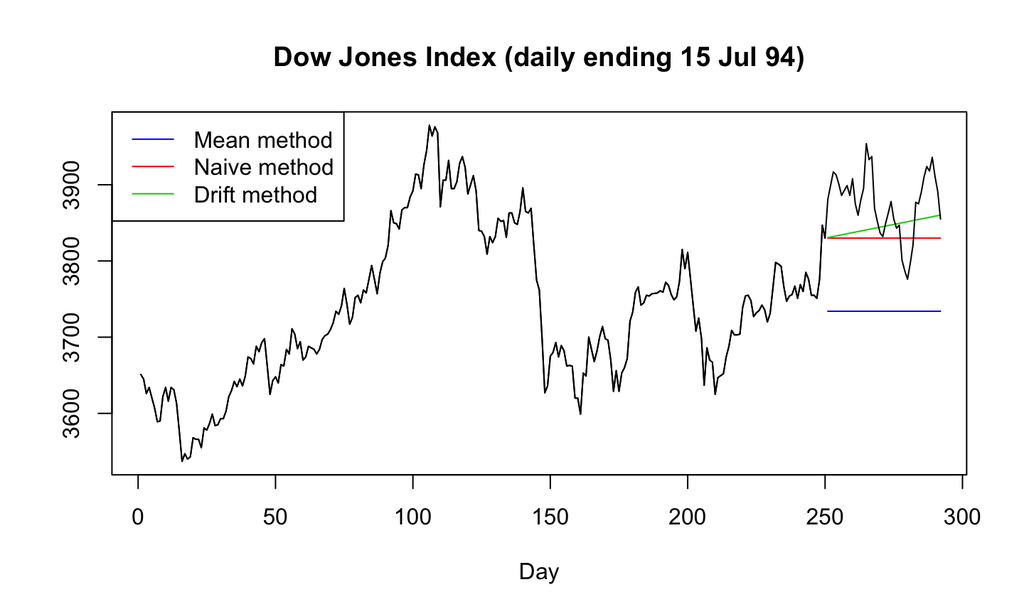

```r
dj2 <- window(dj, end=250)
plot(dj2, main="Dow Jones Index (daily ending 15 Jul 94)",
  ylab="", xlab="Day", xlim=c(2,290))
lines(meanf(dj2,h=42)$mean, col=4)
lines(rwf(dj2,h=42)$mean, col=2)
lines(rwf(dj2,drift=TRUE,h=42)$mean, col=3)
legend("topleft", lty=1, col=c(4,2,3),
  legend=c("Mean method","Naive method","Drift method"))
lines(dj)
```

```r
dj3 <- window(dj, start=251)
rbind(accuracy(meanf(dj2,h=42), dj3)[2,c(2,3,5,6)],
accuracy(rwf(dj2,h=42), dj3)[2,c(2,3,5,6)],
accuracy(rwf(dj2,drift=TRUE,h=42), dj3)[2,c(2,3,5,6)])
```

```
##           RMSE       MAE     MAPE     MASE
## [1,] 148.23574 142.41848 3.663046 8.698111
## [2,]  62.02846  54.44048 1.397937 3.324915
## [3,]  53.69767  45.72743 1.175775 2.792772
```

Here the results were combined into a single matrix.

## Training and test sets

It is important to evaluate forecast accuracy using genuine forecasts. It is invalid to look at how well a model fits the historical data; the accuracy of forecasts can only be determined by considering how well a model performs on new data that were not used when fitting the model.

When choosing models, it is common to use a portion of the available data for fitting, and use the rest of the data for testing the model. Then the testing data can be used to measure how well the model is likely to forecast on new data.

The size of the test set is typically about 20% of the total sample, although this value depends on how long the sample is and how far ahead you want to forecast. The size of the test set should ideally be at least as large as the maximum forecast horizon required.

The following points should be noted.

- A model which fits the data well does not necessarily forecast well.
- A perfect fit can always be obtained by using a model with enough parameters.
- Over-fitting a model to data is as bad as failing to identify the systematic pattern in the data.

Some references describe the test set as the "hold-out set" because these data are "held out" of the data used for fitting. Other references call the training set the "in-sample data" and the test set the "out-of-sample data".

## Cross-validation

A more sophisticated version of training/test sets is cross-validation. For cross-sectional data, cross-validation works as follows:

1. Select observation \(i\) for the test set, and use the remaining observations in the training set. Compute the error on the test observation.
2. Repeat the above step for \(i=1,2,\ldots,N\) where \(N\) is the total number of observations.
3. Compute the forecast accuracy measures based on the errors obtained.

This is a much more efficient use of the available data, as you only omit one observation at each step. However, it can be very time consuming to implement.

For time series data, the procedure is similar but the training set consists only of observations that occurred *prior* to the observation that forms the test set. Thus, no future observations can be used in constructing the forecast.

However, it is not possible to get a reliable forecast based on a very small training set, so the earliest observations are not considered as test sets. Suppose \(k\) observations are required to produce a reliable forecast.

For time series data, the procedure works as follows:

1. Select the observation at time \(k+i\) for the test set, and use the observations at times \(1,2,\ldots,k+i−1\) to estimate the forecasting model. Compute the error on the forecast for time \(k+i\).
2. Repeat the above step for \(i=1,2,\ldots,T−k\) where \(T\) is the total number of observations.
3. Compute the forecast accuracy measures based on the errors obtained.

This procedure is sometimes known as a "rolling forecasting origin" because the "origin" \((k+i−1)\) at which the forecast is based rolls forward in time.

With time series forecasting, one-step forecasts may not be as relevant as multi-step forecasts. In this case, the cross-validation procedure based on a rolling forecasting origin can be modified to allow multi-step errors to be used. Suppose we are interested in models that produce good h-step-ahead forecasts.

1. Select the observation at time \(k+h+i−1\) for the test set, and use the observations at times \(1,2,…,k+i−1\) to estimate the forecasting model. Compute the \(h\)-step error on the forecast for time \(k+h+i−1\).
2. Repeat the above step for \(i=1,2,…,T−k−h+1\) where \(T\) is the total number of observations.
3. Compute the forecast accuracy measures based on the errors obtained.

When \(h=1\), this gives the same procedure as outlined above.

## Residual diagnostics

A residual in forecasting is the difference between an observed value and its forecast based on other observations: \(e_{i} = y_{i}-\hat{y}_{i}\).

For time series forecasting, a residual is based on one-step forecasts; that is \(\hat{y}_{t}\) is the forecast of \(y_{t}\) based on observations \(y_{1},\dots,y_{t-1}\).

For cross-sectional forecasting, a residual is based on all other observations; that is \(\hat{y}_i\) is the prediction of \(y_i\) based on all observations *except* \(y_i\).

A good forecasting method will yield residuals with the following properties:

- The residuals are uncorrelated. If there are correlations between residuals, then there is information left in the residuals which should be used in computing forecasts.
- The residuals have zero mean. If the residuals have a mean other than zero, then the forecasts are biased.

Any forecasting method that does not satisfy these properties can be improved. That does not mean that forecasting methods that satisfy these properties can not be improved.

It is possible to have several forecasting methods for the same data set, all of which satisfy these properties. Checking these properties is important to see if a method is using all available information well, but it is not a good way for selecting a forecasting method.

If either of these two properties is not satisfied, then the forecasting method can be modified to give better forecasts.

Adjusting for bias is easy: if the residuals have mean \(m\), then simply add \(m\) to all forecasts and the bias problem is solved. Fixing the correlation problem is harder and we will not address it until Chapter 8.

In addition to these essential properties, it is useful (but not necessary) for the residuals to also have the following two properties:

- The residuals have constant variance.
- The residuals are normally distributed.

These two properties make the calculation of prediction intervals easier. However, a forecasting method that does not satisfy these properties may not necessarily be improved.

Sometimes applying a transformation such as a logarithm or a square root may assist with these properties, but otherwise there is usually little you can do to ensure your residuals have constant variance and have a normal distribution.

Instead, an alternative approach to finding prediction intervals is necessary.

## Example: Forecasting the Dow-Jones Index

For stock market indexes, the best forecasting method is often the naïve method: each forecast is simply equal to the last observed value, or \(\hat{y}_{t} = y_{t-1}\). Hence, the residuals are simply equal to the difference between consecutive observations: \[e_{t} = y_{t} - \hat{y}_{t} = y_{t} - y_{t-1}.\] The following graphs show the Dow Jones Index (DJI), and the residuals obtained from forecasting the DJI with the naïve method. These graphs show that the naïve method produces forecasts that appear to account for all available information.

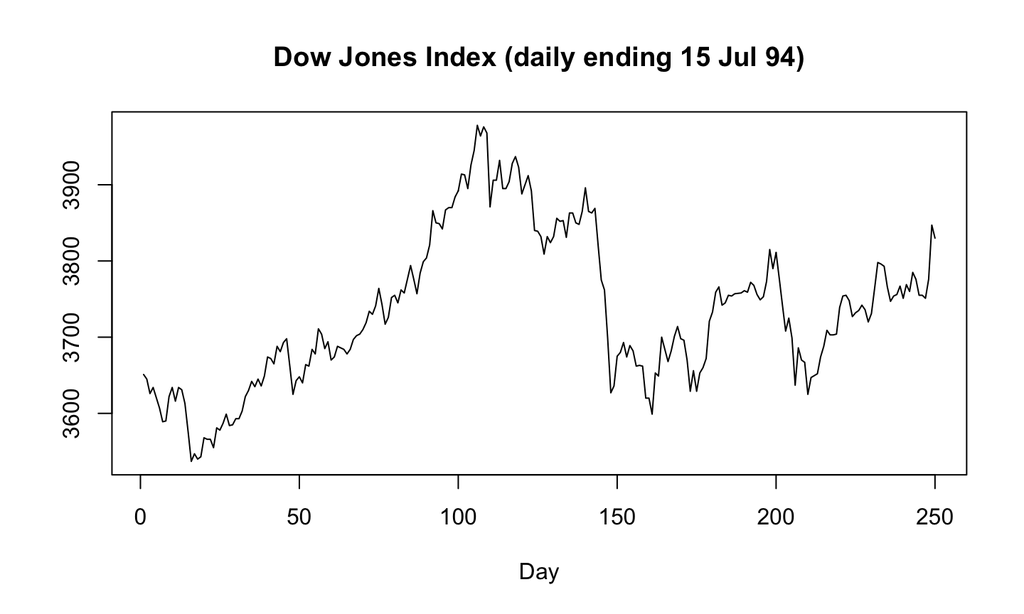

```r
dj2 <- window(dj, end=250)
plot(dj2, main="Dow Jones Index (daily ending 15 Jul 94)",
  ylab="", xlab="Day")
```

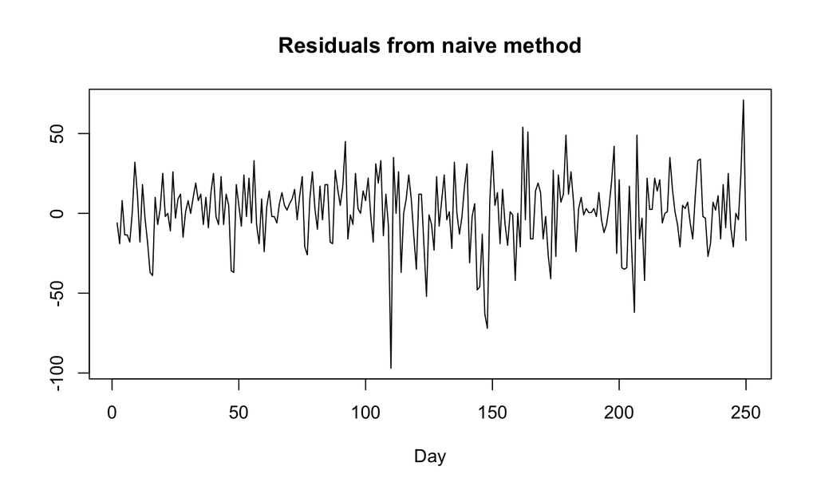

```r
res <- residuals(naive(dj2))
plot(res, main="Residuals from naive method",
  ylab="", xlab="Day")
```

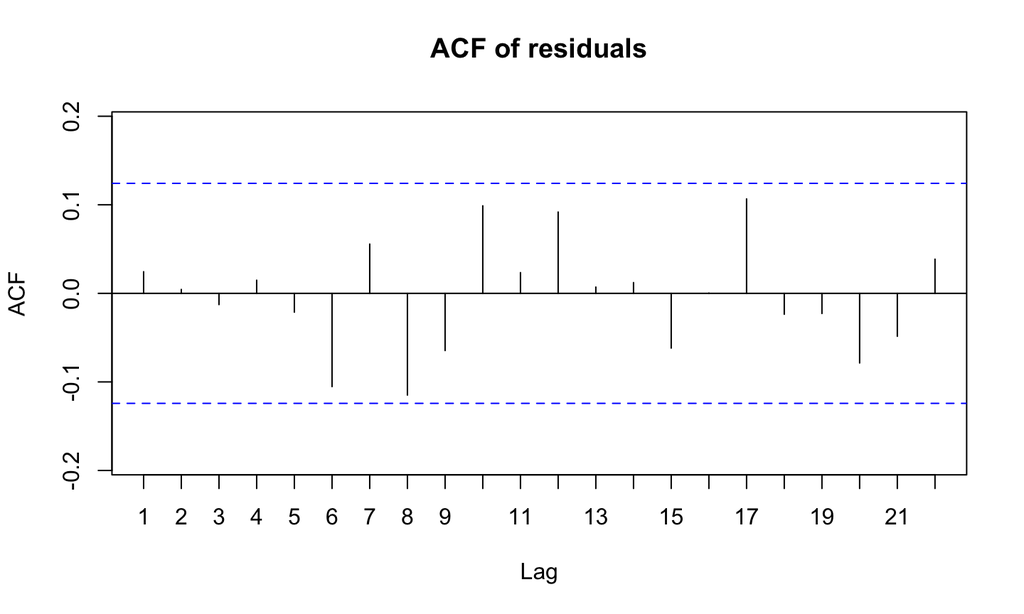

```r
Acf(res, main="ACF of residuals")
```

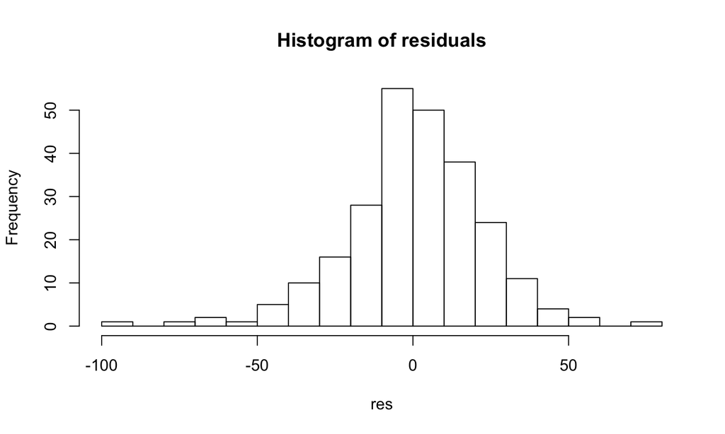

```r
hist(res, nclass="FD", main="Histogram of residuals")
```

## Portmanteau tests for autocorrelation

In addition to looking at the ACF plot, we can do a more formal test for autocorrelation by considering a whole set of \(r_k\) values as a group, rather than treat each one separately.

When we look at the ACF plot to see if each spike is within the required limits, we are implicitly carrying out multiple hypothesis tests, each one with a small probability (5%) of giving a false positive.

When enough of these tests are done, it is likely that at least one will give a false positive and so we may conclude that the residuals have some remaining autocorrelation, when in fact they do not.

In order to overcome this problem, we test whether the first h autocorrelations are significantly different from what would be expected from a white noise process.

A test for a group of autocorrelations is called a *portmanteau test*, from a French word describing a suitcase containing a number of items.

One such test is the *Box-Pierce* test based on the following statistic \[Q = T \sum_{k=1}^h r_k^2,\] where \(h\) is the maximum lag being considered and \(T\) is number of observations. If each \(r_k\) is close to zero, then \(Q\) will be small. If some \(r_k\) values are large (positive or negative), then \(Q\) will be large.

A related (and more accurate) test is the Ljung-Box test based on \[Q^* = T(T+2) \sum_{k=1}^h (T-k)^{-1}r_k^2.\] Again, large values of \(Q^∗\) suggest that the autocorrelations do not come from a white noise series.

How large is too large? If the autocorrelations did come from a white noise series, then both \(Q\) and \(Q^∗\) would have a \(\chi^2\) distribution with \((h−K)\) degrees of freedom where \(K\) is the number of parameters in the model. If they are calculated from raw data (rather than the residuals from a model), then set \(K=0\).

```r
# lag=h and fitdf=K
Box.test(res, lag=10, fitdf=0)
##
##  Box-Pierce test
##
## data:  res
## X-squared = 10.6548, df = 10, p-value = 0.385
Box.test(res, lag=10, fitdf=0, type="Lj")
##
##  Box-Ljung test
##
## data:  res
## X-squared = 11.0879, df = 10, p-value = 0.3507
```

For the Dow-Jones example, the naive model has no parameters, so \(K=0\). For both \(Q\) and \(Q^∗\), the results are not significant (i.e., the p-values are relatively large). So the residuals are not distinguishable from white noise series.

## Prediction intervals

A prediction interval gives an interval within which we expect \(y_i\) to lie with a specified probability.

Assuming the forecast errors are uncorrelated and normally distributed, then a simple 95% prediction interval for the next observation in a time series is \(\hat{y}_{t} \pm 1.96 \hat{\sigma}\), where \(\hat{\sigma}\) is an estimate of the standard deviation of the forecast distribution.

When forecasting one-step ahead, the standard deviation of the forecast distribution is almost the same as the standard deviation of the residuals.

The value of prediction intervals is that they express the uncertainty in the forecasts. If we only produce point forecasts, there is no way of telling how accurate the forecasts are. But if we also produce prediction intervals, then it is clear how much uncertainty is associated with each forecast.

To produce a prediction interval, it is necessary to have an estimate of the standard deviation of the forecast distribution.

- For one-step forecasts for time series, the residual standard deviation provides a good estimate of the forecast standard deviation.
- For all other situations, including multi-step forecasts for time series, a more complicated method of calculation is required.

A common feature of prediction intervals is that they increase in length as the forecast horizon increases. The further ahead we forecast, the more uncertainty is associated with the forecast, and so the prediction intervals grow wider.

If a transformation has been used, then the prediction interval should be computed on the transformed scale, and the end points back-transformed to give a prediction interval on the original scale.

This approach preserves the probability coverage of the prediction interval, although it will no longer be symmetric around the point forecast.